# Project 1

Author

Alexandre Snyder, Kunal Ghosh, Seokyoung Kim

# Libraries

```r
library(tidyverse)
library(tidymodels)
```

# Data Load / Wrangling

```r
population <- read_csv("data/raw/pop.csv") |>
  select(geo, name, population = `2025`)
life_expectancy <- read_csv("data/raw/lex.csv") |>
  select(geo, name, life_expectancy = `2025`)
sanitation_access <- read_csv("data/raw/at_least_basic_sanitation_overall_access_percent.csv") |>
  select(geo, name, sanitation_access_pct = `2024`)
murder_deaths <- read_csv("data/raw/murder_total_deaths.csv") |>
  select(geo, name, murder_total_deaths = `2023`)
food_supply <- read_csv("data/raw/food_supply_kilocalories_per_person_and_day.csv") |>
  select(geo, name, food_supply_kcal_per_person_day = `2022`)
child_deaths <- read_csv("data/raw/number_of_child_deaths.csv") |>
  select(geo, name, number_of_child_deaths = `2022`)
female_head_of_state <- read_csv("data/raw/female_hos.csv") |>
  select(geo, name, female_head_of_state = `2021`)
project1_2025 <- life_expectancy |>
  left_join(population, by = c("geo", "name")) |>
  left_join(sanitation_access, by = c("geo", "name")) |>
  left_join(murder_deaths, by = c("geo", "name")) |>
  left_join(food_supply, by = c("geo", "name")) |>
  left_join(child_deaths, by = c("geo", "name")) |>
  left_join(female_head_of_state, by = c("geo", "name"))

# Converts raw counts into population-adjusted rates so countries can be compared
# fairly regardless of their population size.
project1_2025 <- project1_2025 |>
  mutate(murder_deaths_per_100k = (murder_total_deaths / population) * 100000,
         child_deaths_per_100k = (number_of_child_deaths / population) * 100000)

project1_2025 <- project1_2025 |>
  mutate(female_hos_binary = if_else(female_head_of_state == "Had a female head of state", 1, 0, missing = NA_real_))

# Delete unnecessary columns
project1_2025 <- project1_2025 |>
  select(-murder_total_deaths, -number_of_child_deaths, -population, -female_head_of_state)
```

# Exploratory Data Analysis

The analytic data set has one row per country (n = 194). The `geo` and `name` columns are nominal identifier variables. `geo` contains a unique three-letter country code and `name` contains a unique country name. Neither has missing values.

The response and four continuous predictors are quantitative, and`female_hos_binary` is categorical. The female-head-of-state indicator has 78 missing values, sanitation has 17 missing values, and food supply has 11 missing values while life expectancy and the two death rates are missing for only one country each.

## Response variable: life expectancy

```r
summary(life_expectancy)
```

```
     geo                name           life_expectancy
 Length:194         Length:194         Min.   :55.48
 Class :character   Class :character   1st Qu.:68.81
 Mode  :character   Mode  :character   Median :74.97
                                       Mean   :73.62
                                       3rd Qu.:78.80
                                       Max.   :85.71
                                       NA's   :1
```

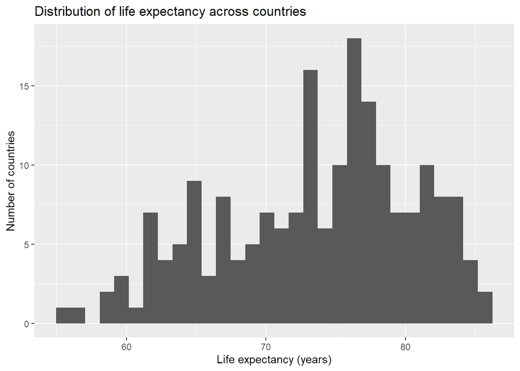

```r
project1_2025 |>
  ggplot(aes(x = life_expectancy)) +
  geom_histogram() +
  labs(
    title = "Distribution of life expectancy across countries",
    x = "Life expectancy (years)",
    y = "Number of countries")
```

The mean is 73.62 years, and the median is slightly higher at 74.97 years (SD = 6.96). Countries are not all clustered around the same life expectancy.

## Predictor: overall access to basic sanitation

```r
summary(sanitation_access)
```

```
     geo                name           sanitation_access_pct
 Length:193         Length:193         Min.   : 10.36
 Class :character   Class :character   1st Qu.: 65.71
 Mode  :character   Mode  :character   Median : 92.62
                                       Mean   : 79.49
                                       3rd Qu.: 99.01
                                       Max.   :100.00
                                       NA's   :16
```

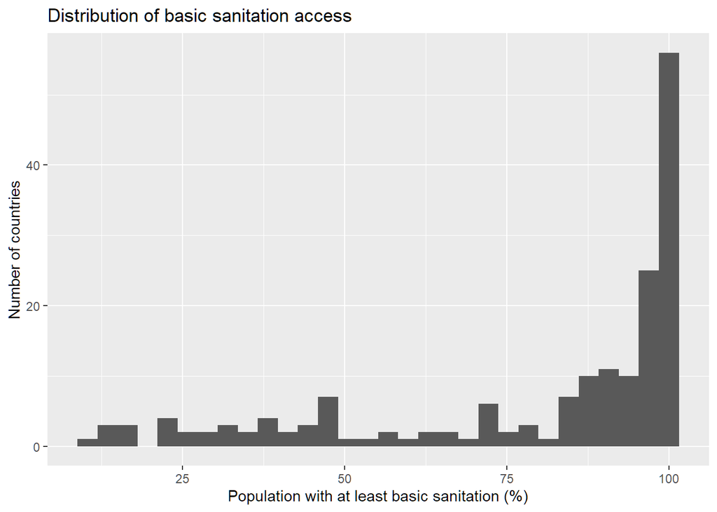

```r
project1_2025 |>
  ggplot(aes(x = sanitation_access_pct)) +
  geom_histogram() +
  labs(
    title = "Distribution of basic sanitation access",
    x = "Population with at least basic sanitation (%)",
    y = "Number of countries")
```

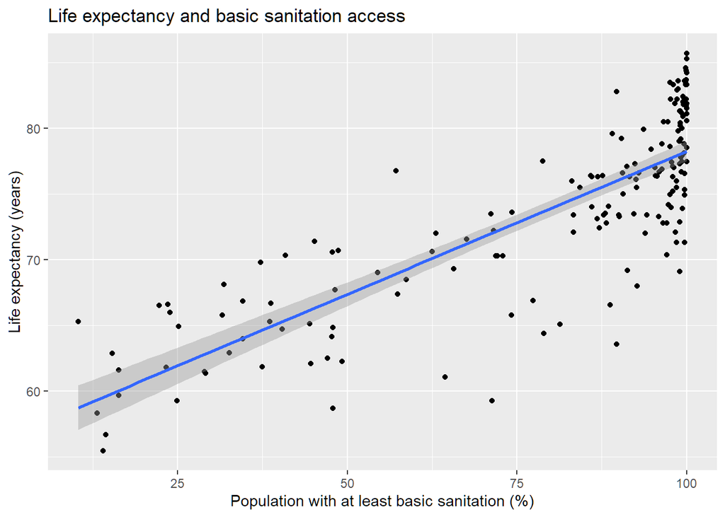

```r
project1_2025 |>
  ggplot(aes(x = sanitation_access_pct, y = life_expectancy)) +
  geom_point() +
  geom_smooth(method = "lm") +
  labs(
    title = "Life expectancy and basic sanitation access",
    x = "Population with at least basic sanitation (%)",
    y = "Life expectancy (years)"
  )
```

The mean is 79.49% and SD of 26.51 percentage points. The scatterplot shows a strong positive linear association with life expectancy, which means countries with greater sanitation access tend to have longer life expectancy.

## Predictor: food supply

```r
summary(food_supply)
```

```
     geo                name           food_supply_kcal_per_person_day
 Length:184         Length:184         Min.   :1755
 Class :character   Class :character   1st Qu.:2621
 Mode  :character   Mode  :character   Median :2953
                                       Mean   :2941
                                       3rd Qu.:3324
                                       Max.   :3923
                                       NA's   :1
```

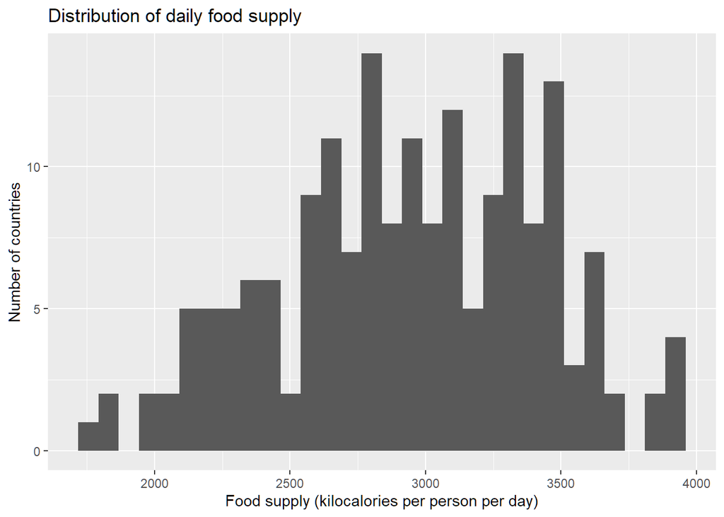

```r
project1_2025 |>
  ggplot(aes(x = food_supply_kcal_per_person_day)) +
  geom_histogram() +
  labs(
    title = "Distribution of daily food supply",
    x = "Food supply (kilocalories per person per day)",
    y = "Number of countries"
  )
```

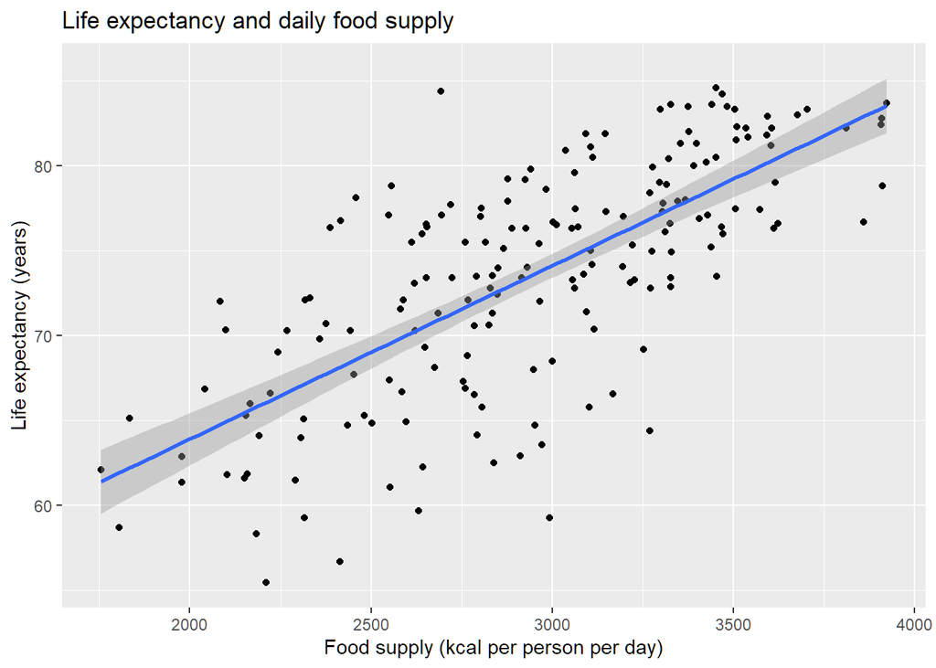

```r
project1_2025 |>
  ggplot(aes(x = food_supply_kcal_per_person_day, y = life_expectancy)) +
  geom_point() +
  geom_smooth(method = "lm") +
  labs(
    title = "Life expectancy and daily food supply",
    x = "Food supply (kcal per person per day)",
    y = "Life expectancy (years)"
  )
```

The mean is 2,941 kilocalories per person per day with an SD of 480.43. The scatterplot shows a positive association with life expectancy but there is big vertical spread at similar food supply levels.

## Predictor: murder deaths per 100,000 people

```r
project1_2025 |>
select(murder_deaths_per_100k) |>
  summary()
```

```
 murder_deaths_per_100k
 Min.   : 0.1489
 1st Qu.: 1.2633
 Median : 3.4113
 Mean   : 7.6599
 3rd Qu.: 8.5911
 Max.   :56.0953
 NA's   :1
```

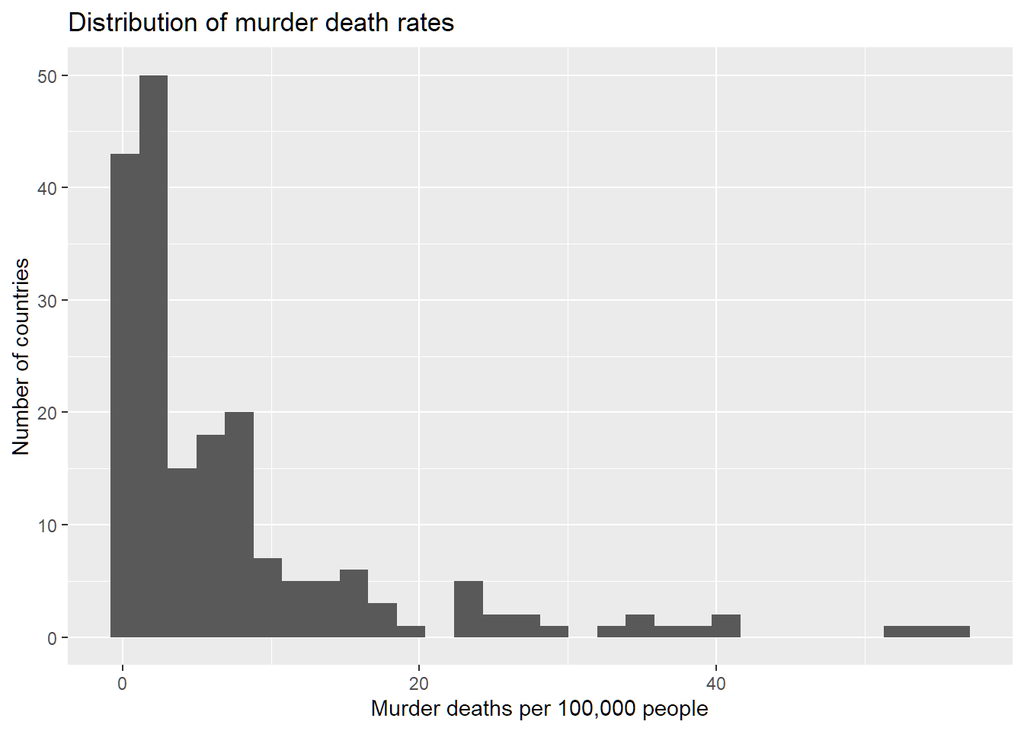

```r
project1_2025 |>
  ggplot(aes(x = murder_deaths_per_100k)) +
  geom_histogram() +
  labs(
    title = "Distribution of murder death rates",
    x = "Murder deaths per 100,000 people",
    y = "Number of countries"
  )
```

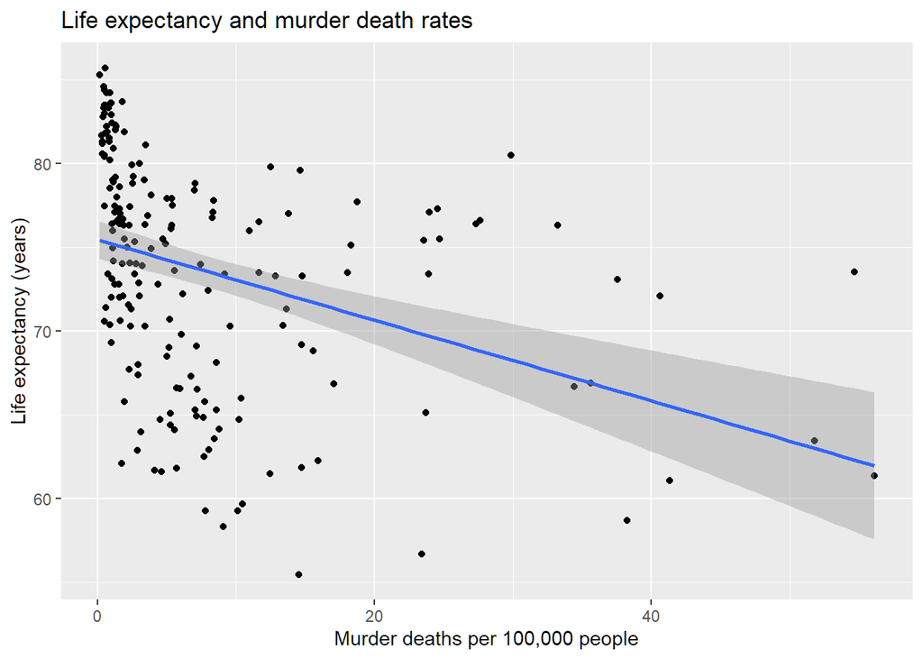

```r
project1_2025 |>
  ggplot(aes(x = murder_deaths_per_100k, y = life_expectancy)) +
  geom_point() +
  geom_smooth(method = "lm") +
  labs(
    title = "Life expectancy and murder death rates",
    x = "Murder deaths per 100,000 people",
    y = "Life expectancy (years)"
  )
```

The mean is 7.66 and the SD is 10.45. The relationship with life expectancy is negative but not strong. The wide scatter shows murder death rate alone is unlikely to explain the variation in life expectancy.

## Predictor: child deaths per 100,000 people

```r
project1_2025 |>
select(child_deaths_per_100k) |>
  summary()
```

```
 child_deaths_per_100k
 Min.   :  1.206
 1st Qu.:  6.063
 Median : 24.722
 Mean   : 62.152
 3rd Qu.: 92.311
 Max.   :392.108
 NA's   :1
```

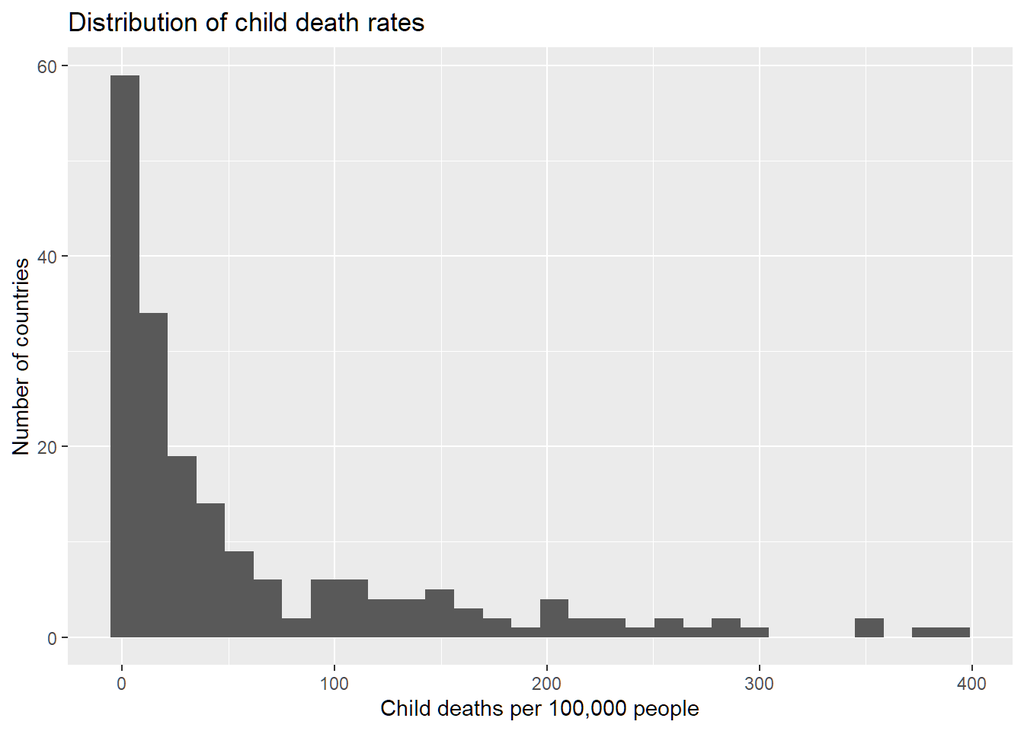

```r
project1_2025 |>
  ggplot(aes(x = child_deaths_per_100k)) +
  geom_histogram() +
  labs(
    title = "Distribution of child death rates",
    x = "Child deaths per 100,000 people",
    y = "Number of countries"
  )
```

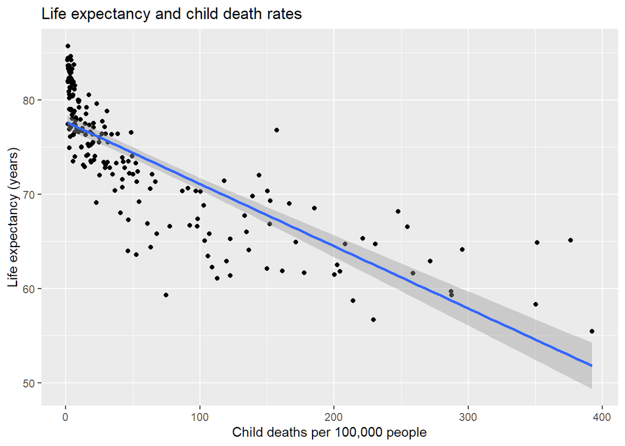

```r
project1_2025 |>
  ggplot(aes(x = child_deaths_per_100k, y = life_expectancy)) +
  geom_point() +
  geom_smooth(method = "lm") +
  labs(
    title = "Life expectancy and child death rates",
    x = "Child deaths per 100,000 people",
    y = "Life expectancy (years)"
  )
```

The mean is 62.15 and the SD is 83.51. The scatterplot shows a strong negative association with life expectancy.

## Predictor: female head of state

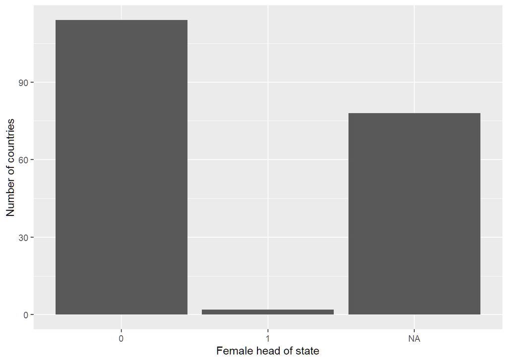

```r
project1_2025 |>
  ggplot(aes(x = factor(female_hos_binary))) +
  geom_bar() +
  labs(
    x = "Female head of state",
    y = "Number of countries"
  )
```

`female_hos_binary` is a categorical, binary variable based on the 2021 female-head-of-state indicator. 0 means the country did not have a female head of state, and 1 means it did. There are 78 missing values. Of the 116 observed records, 114 were 0 and only two were coded 1. This variable cannot support a reliable comparison due to the significant amount of missing values and imbalance.

# Linear Models

```r
model1 <- lm(life_expectancy ~ sanitation_access_pct, data = project1_2025)
model2 <- lm(life_expectancy ~ sanitation_access_pct + food_supply_kcal_per_person_day, data = project1_2025)
model3 <- lm(life_expectancy ~ sanitation_access_pct + food_supply_kcal_per_person_day + murder_deaths_per_100k + child_deaths_per_100k + female_hos_binary, data = project1_2025)
```

# Summary

## Model 1

```r
summary(model1)
```

```
Call:
lm(formula = life_expectancy ~ sanitation_access_pct, data = project1_2025)

Residuals:
     Min       1Q   Median       3Q      Max
-12.7268  -2.3283   0.0347   3.0647   7.8111

Coefficients:
                      Estimate Std. Error t value Pr(>|t|)
(Intercept)           56.49648    0.96895   58.31   <2e-16 ***
sanitation_access_pct  0.21761    0.01158   18.79   <2e-16 ***
---
Signif. codes:  0 '***' 0.001 '**' 0.01 '*' 0.05 '.' 0.1 ' ' 1

Residual standard error: 4.067 on 174 degrees of freedom
  (18 observations deleted due to missingness)
Multiple R-squared:  0.6699,    Adjusted R-squared:  0.668
F-statistic: 353.1 on 1 and 174 DF,  p-value: < 2.2e-16
```

## Model 2

```r
summary(model2)
```

```
Call:
lm(formula = life_expectancy ~ sanitation_access_pct + food_supply_kcal_per_person_day,
    data = project1_2025)

Residuals:
    Min      1Q  Median      3Q     Max
-13.190  -2.228   0.228   2.839   8.774

Coefficients:
                                 Estimate Std. Error t value Pr(>|t|)
(Intercept)                     4.947e+01  1.856e+00  26.660  < 2e-16 ***
sanitation_access_pct           1.680e-01  1.539e-02  10.913  < 2e-16 ***
food_supply_kcal_per_person_day 3.683e-03  8.402e-04   4.383 2.07e-05 ***
---
Signif. codes:  0 '***' 0.001 '**' 0.01 '*' 0.05 '.' 0.1 ' ' 1

Residual standard error: 3.77 on 166 degrees of freedom
  (25 observations deleted due to missingness)
Multiple R-squared:  0.7134,    Adjusted R-squared:  0.7099
F-statistic: 206.6 on 2 and 166 DF,  p-value: < 2.2e-16
```

## Model 3

```r
summary(model3)
```

```
Call:
lm(formula = life_expectancy ~ sanitation_access_pct + food_supply_kcal_per_person_day +
    murder_deaths_per_100k + child_deaths_per_100k + female_hos_binary,
    data = project1_2025)

Residuals:
     Min       1Q   Median       3Q      Max
-13.0068  -2.0407  -0.0338   2.3967   8.6309

Coefficients:
                                 Estimate Std. Error t value Pr(>|t|)
(Intercept)                     64.262470   4.114328  15.619  < 2e-16 ***
sanitation_access_pct            0.104669   0.028503   3.672 0.000408 ***
food_supply_kcal_per_person_day  0.001051   0.001222   0.859 0.392362
murder_deaths_per_100k          -0.091557   0.040404  -2.266 0.025848 *
child_deaths_per_100k           -0.024851   0.008133  -3.056 0.002956 **
female_hos_binary               -0.081748   2.733186  -0.030 0.976206
---
Signif. codes:  0 '***' 0.001 '**' 0.01 '*' 0.05 '.' 0.1 ' ' 1

Residual standard error: 3.805 on 90 degrees of freedom
  (98 observations deleted due to missingness)
Multiple R-squared:  0.6997,    Adjusted R-squared:  0.683
F-statistic: 41.94 on 5 and 90 DF,  p-value: < 2.2e-16
```

# LINE Assumptions

## Model 1

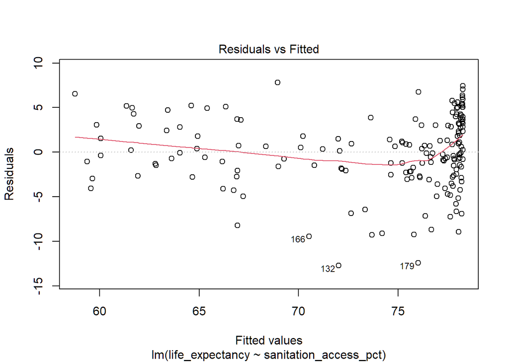

```r
plot(model1, which = 1)
```

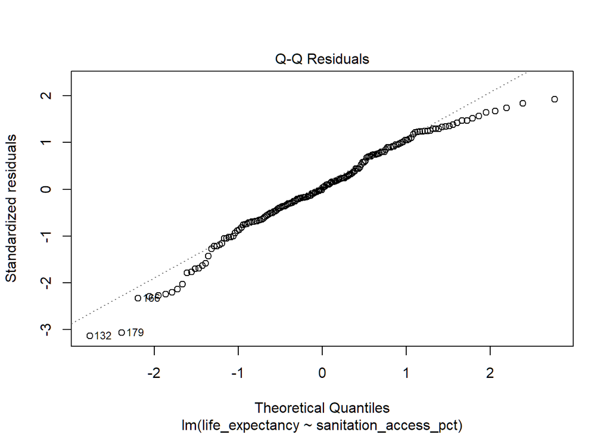

```r
plot(model1, which = 2)
```

## Model 2

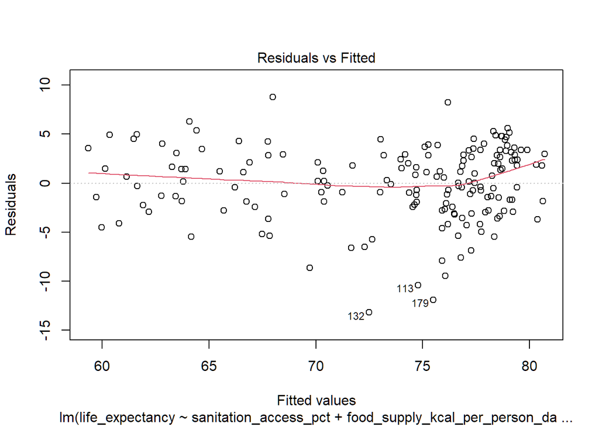

```r
plot(model2, which = 1)
```

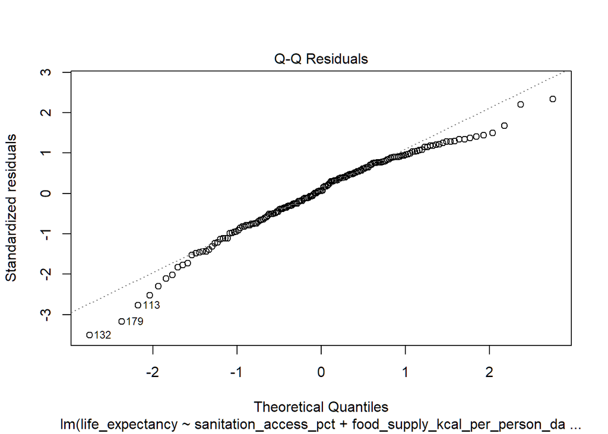

```r
plot(model2, which = 2)
```

## Model 3

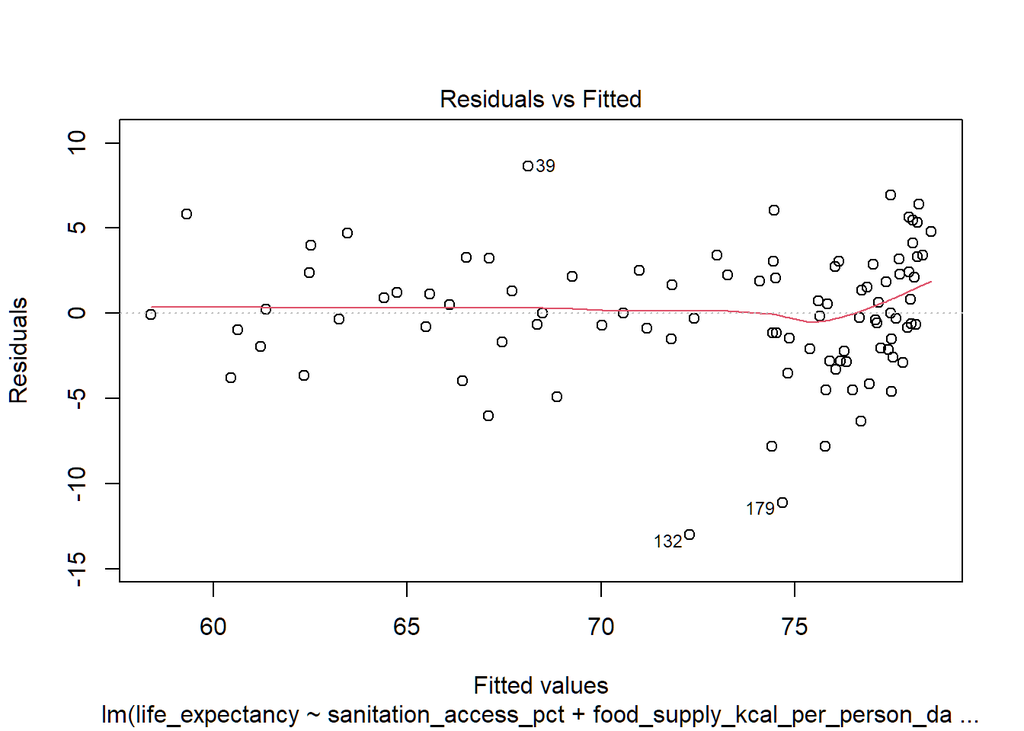

```r
plot(model3, which = 1)
```

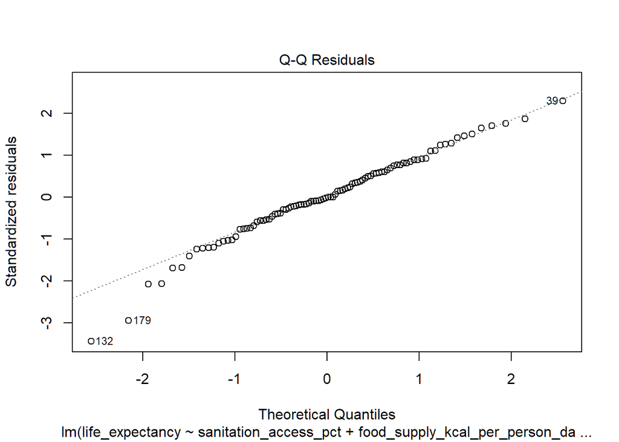

```r
plot(model3, which = 2)
```

## What is the best model?

Model 2. It has highest adjusted r squared value ($R^2_{adj} = 0.710$), lowest residual standard error ($RSE = 3.77$), and its predictor variables are statistically significant ($p < 0.05$). Although there is a curvature in Residuals vs. Fitted plot and tail movement in Q-Q residuals plot, it is the most balanced one among the three models.

# Our Question

**Is there any association between child deaths and food supply?**

## Visualization

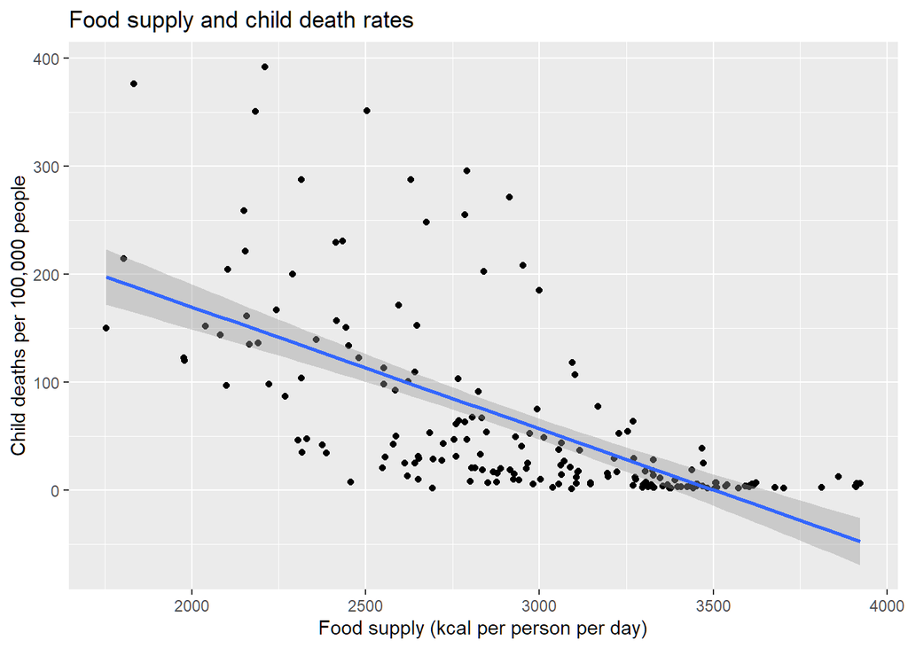

```r
project1_2025 |>
  ggplot(aes(x = food_supply_kcal_per_person_day, y = child_deaths_per_100k)) +
  geom_point() +
  geom_smooth(method = "lm") +
  labs(
    title = "Food supply and child death rates",
    x = "Food supply (kcal per person per day)",
    y = "Child deaths per 100,000 people"
  )
```

## Linear Model

```r
model0 <- lm(child_deaths_per_100k ~ food_supply_kcal_per_person_day, data = project1_2025)
summary(model0)
```

```
Call:
lm(formula = child_deaths_per_100k ~ food_supply_kcal_per_person_day,
    data = project1_2025)

Residuals:
    Min      1Q  Median      3Q     Max
-110.50  -41.97  -10.88   16.52  246.12

Coefficients:
                                 Estimate Std. Error t value Pr(>|t|)
(Intercept)                     395.76639   29.93021   13.22   <2e-16 ***
food_supply_kcal_per_person_day  -0.11301    0.01004  -11.25   <2e-16 ***
---
Signif. codes:  0 '***' 0.001 '**' 0.01 '*' 0.05 '.' 0.1 ' ' 1

Residual standard error: 65.1 on 181 degrees of freedom
  (11 observations deleted due to missingness)
Multiple R-squared:  0.4116,    Adjusted R-squared:  0.4083
F-statistic: 126.6 on 1 and 181 DF,  p-value: < 2.2e-16
```

## Answer

There is a statistically significant negative association. The fitted model estimates that an additional 100 kilocalories per person per day is associated with about 11.3 fewer child deaths per 100,000 people. Food supply explains about 41% of the variation in child-death rates ($R^2 = 0.412$). This is an association, not proof that food supply causes lower child mortality.